# Comparaison de trois modèles de classification

## Analyse de sentiment

### **Commun à tout les modèles** :

- Echantillons d'entrainements:
  - 1.5 Millions de tweet prédits positifs ou négatifs.
  - Set d'entrainement : 80%, Validation : 10%, Test: 10%
- Métriques évaluées :  
  Etant donné que le dataset est équilibré, j'évaluerai les modéles sur la métrique accuracy (rapport entre le nombre de prédictions correctes et le nombre total d'observations), les autres métriques sont affichées à titre informatif.
- Démarche MLOPS mise en oeuvre :  
  Utilisation de **MLflow** qui est une plateforme open source qui aide à gérer le cycle de vie complet de l'apprentissage automatique, de l'expérimentation à la production. Elle est particulièrement utile pour suivre les expériences, packager le code en unités réutilisables et partager et déployer des modèles.
  - Traçage (Tracking) des expérimentations: MLflow permet de suivre et d'enregistrer les paramètres, les métriques et les artefacts associés à chaque run, ce qui facilite la comparaison des différentes expériences.
  - Reproduction: Grâce à l'enregistrement des expériences, il est facile de reproduire et de réexécuter un modèle avec les mêmes paramètres et les mêmes données.
  - Packaging: MLflow permet de packager le code, les environnements et les modèles en format standard, ce qui facilite le partage et le déploiement.
  - Déploiement: MLflow offre des outils pour déployer des modèles dans divers environnements, tels que des serveurs locaux, des cloud platforms ou des conteneurs.
  - Gestion du modèle (Model Registry): MLflow inclut un registre de modèles pour centraliser et gérer la collaboration sur les cycles de vie des modèles.
  - Intégration et automatisation: L'intégration de MLflow avec d'autres outils MLOps, tels que CI/CD, facilite l'automatisation du déploiement, des tests et de la surveillance.
  - Collaboration: MLflow étant une plateforme open source, elle permet aux équipes de collaborer facilement, de partager des travaux et de bénéficier des contributions de la communauté.

### Modèle sur mesure simple

La régression logistique est un modèle statistique qui utilise une fonction sigmoid pour prédire des classes binaires. Ainsi, la régression logistique est une méthode de régression courante et utile pour prédire des classes binaires, c'est-à-dire deux classes, dans notre cas, tweet positif ou négatif.  
Il existe de nombreuses façons de transformer des chaînes de caractères en données numériques pour former nos modèles. Pour la regression logistique, nous allons étudier la méthode Term Frequency-Inverse Document Frequency. Le TF-IDF est un score qui sert à mesurer la pertinence d’un mot ou d’un terme clé dans un article en se basant sur sa rareté dans tout le corpus. Il est très précis, car son utilisation permet d’écarter les mots vides qui apparaissent en très grand nombre dans tous les textes, quelle que soit la thématique traitée.

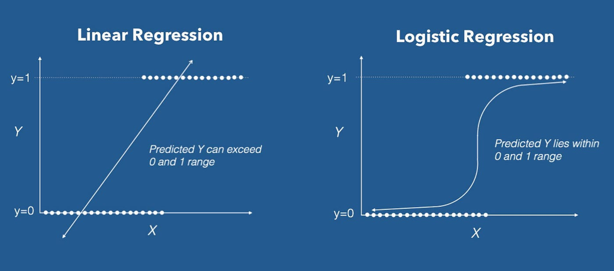

#### Différentes formes de preprocessing

La lemmatisation est un processus plus complexe que la simple troncature (stemming) qui consiste à enlever les préfixes et les suffixes des mots sans tenir compte du contexte. La lemmatisation, en revanche, tient compte du contexte et de la partie du discours (si le mot est un nom, un verbe, un adjectif, etc.) pour déterminer le lemme correct.

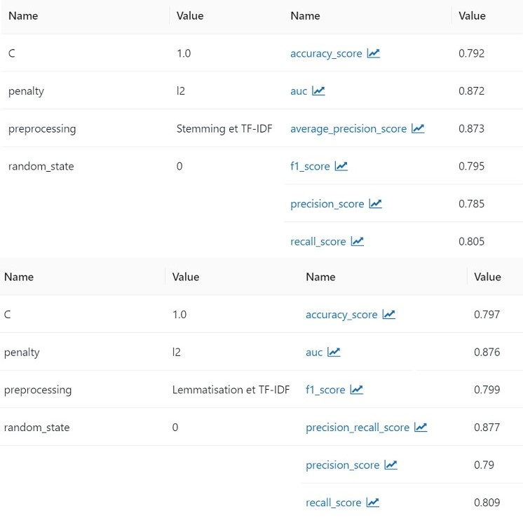

Même avec la regression logistique qui est un modèle linéaire plus simple que les autres, la lemmatisation semble apporter une légère amélioration des performances. Etant donné que les modèles que nous allons aborder par la suite sont plus complexes, nous travaillerons avec la lemmatisation exclusivement car le stemming provoque une perte d'information sémantique.

### Modèle sur Mesure avancé

#### Matrice d'embedding

Avec la regression logistique, nous avons utiliser TF-IDF pour représenter numériquement nos données. Cependant avec un réseau de neurones profonds cette technique peut montrer ses limites (représentation sparse, perte de l'ordre des mots, grande dimensionnalité, risque de manque de généralisation). En fait, les réseaux de neurones profonds peuvent extraire et apprendre des caractéristiques plus complexes et hiérarchiques des données. Voila pourquoi la technique TF-IDF n'est pas idéale.

De plus, afin de généraliser l'apprentissage de notre modèle, nous allons utiliser une matrice d'embedding pré-entrainée sur un vaste corpus de texte. Les poids de notre matrice seront entrainables lors de l'entrainement du modèle. Nous avons testé deux modèles d'embedding pré-entrainés :

- GloVe : C'est un modèle d'apprentissage non supervisé permettant d'obtenir des représentations vectorielles pour les mots. Il est basé sur des statistiques globales de cooccurrence mot-mot d'un corpus. Le modèle GloVe est basé un corpus de texte spécifiquement basé sur Twitter ce qui peut être plus utile dans notre cas.
- Fasttext : Contrairement à d'autres modèles de plongement de mots qui travaillent avec des mots entiers, FastText ,lui, prend en compte les n-grammes de caractères dans chaque mot. Ces n-grammes permettent au modèle de capturer les nuances morphologiques des mots, comme les préfixes et les suffixes. D'où l'utilité de travailler avec la lemmatisation et non le stemming. Le corpus de texte sur lequel est basé Fasttext est tiré des archives Common Crawl.

**LSTM**  
Contrairement aux réseaux neuronaux traditionnels, LSTM intègre des connexions de rétroaction, c'est à dire qu'elle permet à l'information de persister, ce qui lui permet de traiter des séquences entières de données, et pas seulement des points de données individuels. Cela le rend très efficace pour comprendre et prédire des modèles dans des données séquentielles comme les séries temporelles, le texte et la parole.

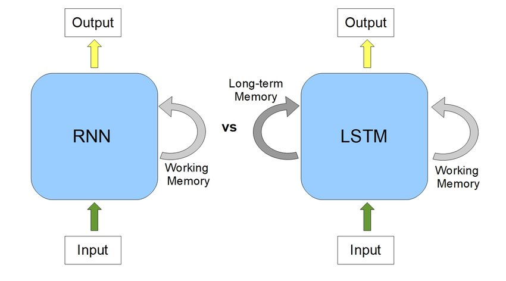

```python
%%time
experiment_name = "Keras LSTM"
mlflow.set_experiment(experiment_name)
with mlflow.start_run(run_name="LSTM-Fasttext"):

    batch_size = 256
    lstm_out = 128
    dropout_rate = 0.3

    model = Sequential()
    model.add(Embedding(
        input_dim=vocab_size,
        output_dim=embedding_dim,
        input_length=padded_sequences_train.shape[1],
        weights=[embedding_matrix]))
    model.add(SpatialDropout1D(dropout_rate))
    model.add(Conv1D(128, 5, activation='relu'))
    model.add(MaxPooling1D(pool_size=4))
    model.add(LSTM(lstm_out))
    model.add(Dropout(dropout_rate))
    model.add(Dense(16, activation='relu'))
    model.add(Dense(1, activation='sigmoid'))
    model.compile(loss='binary_crossentropy', optimizer='adam', metrics=['accuracy'])
    print(model.summary())
    early_stopping = EarlyStopping(monitor='val_acc', patience=1)

    hist = model.fit(
        padded_sequences_train,
        y_train,
        epochs=10,
        batch_size=batch_size,
        validation_data=(padded_sequences_valid, y_valid),
        callbacks=[early_stopping],
        verbose=1
    )

    y_pred_prob = model.predict(padded_sequences_test)
    y_pred_bin = (y_pred_prob > 0.5).astype(int)

    scores = model.evaluate(padded_sequences_test, y_test, verbose=0)
    print("Accuracy on test data: %.2f%%" % (scores[1] * 100))

    accuracy, precision, recall, f1, score_auc, aucpr_score = calcul_metrics(y_test, y_pred_bin, y_pred_prob, recover=True)

    mlflow.log_metrics({
    "accuracy_score": scores[1] * 100,
    "precision_score": precision,
    "recall_score": recall,
    "f1_score": f1,
    "auc": score_auc,
    "precision_recall_score": aucpr_score,
    })

    mlflow.log_params({
        "batch_size": batch_size,
        "embedding_dim": embedding_dim,
        "vocab_size": vocab_size,
        "input_length": padded_sequences_train.shape[1],
        "SpatialDropout1D_rate": dropout_rate,
        "Conv1D_filters": 128,
        "Conv1D_kernel_size": 5,
        "MaxPooling1D_pool_size": 4,
        "lstm_units": lstm_out,
        "Dropout_rate": dropout_rate,
        "Dense_units": 16,
        "loss_function": 'binary_crossentropy',
        "optimizer": 'adam',
        "epochs": 10,
        "early_stopping_monitor": 'val_acc',
        "early_stopping_patience": 1
    })
    signature = infer_signature(padded_sequences_test, y_pred_prob)
    model_name = "LSTM-Fasttext"
    plot_hist(hist, model_name)
    mlflow.log_artifact(f'{model_name}_training_accuracy_loss.png')

    mlflow.keras.log_model(
    model,
    signature = signature,
    artifact_path="LSTM-Fasttext",
    registered_model_name="LSTM-Fasttext",
)
```

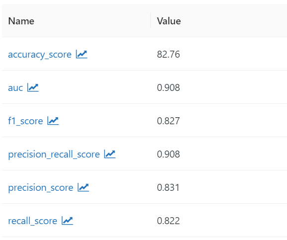

On note une amélioration notable des performances comparé à la régression logistique.

### Modèle BERT

BERT, qui signifie Bidirectional Encoder Representations from Transformers, est un modèle d'apprentissage profond dans lequel chaque élément de sortie est connecté à chaque élément d'entrée, et les pondérations entre eux sont calculées dynamiquement sur la base de leur connexion (mécanisme d'attention).  
Historiquement, les modèles de langage ne pouvaient lire un texte que de manière séquentielle, soit de gauche à droite, soit de droite à gauche, mais ne pouvaient pas faire les deux en même temps. BERT est différent car il est conçu pour lire dans les deux sens à la fois. Cette capacité, rendue possible par l'introduction des transformateurs, est connue sous le nom de bidirectionnalité. Cette compréhension bidirectionnelle permet à BERT de saisir le contexte d'une manière plus riche. BERT a été entrainé sur une grande quantité de texte (comme Wikipedia).

Au cours de cette étape, BERT apprend deux tâches:

- Prédiction de mots manquants (Masked Language Modeling): Des mots aléatoires sont masqués (remplacés par un jeton spécial [MASK]), et BERT tente de prédire ces mots en fonction du contexte.
- Prédiction de la relation entre les phrases: BERT prédit si une phrase donnée suit logiquement une autre phrase.

A la suite de ce pré entrainement, le modèle peut être "fine-tuned" pour notre tâche.

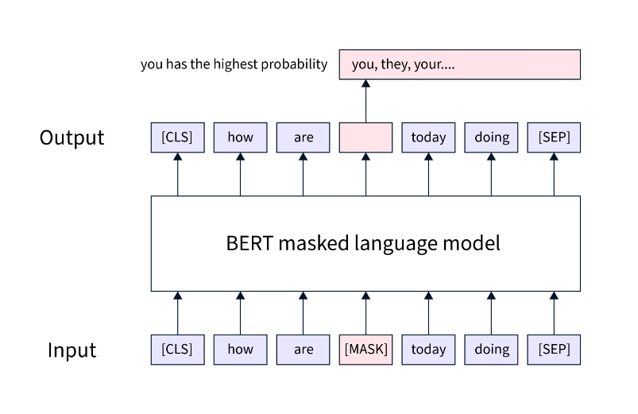

Ci dessous, la fonction d'encodage ainsi que le processus de construction du modèle BERT pour la classification binaire :

#### Encodage et construction du modèle

```python
def bert_encode(data, maximum_len, batch_size):
    input_ids = []
    attention_masks = []

    for i in range(0, len(data), batch_size):
        batch = data[i:i+batch_size]
        for text in batch:
            encoded = tokenizer.encode_plus(text,
                                            add_special_tokens=True,
                                            padding='max_length',
                                            max_length=maximum_len,
                                            return_attention_mask=True,
                                            truncation=True)

            input_ids.append(encoded['input_ids'])
            attention_masks.append(encoded['attention_mask'])

    return np.array(input_ids), np.array(attention_masks)

def build_bert_model(model_layer, learning_rate, add_dense = ADD_DENSE,
               dense_dim = DENSE_DIM, add_dropout = ADD_DROPOUT, dropout = DROPOUT):


    input_ids = Input(shape=(40,),dtype='int32')
    attention_masks = Input(shape=(40,),dtype='int32')
    transformer_layer = model_layer([input_ids,attention_masks])
    output = transformer_layer[1]

    if add_dense:
        print("Training with additional dense layer...")
        output = Dense(dense_dim,activation='relu')(output)

    if add_dropout:
        print("Training with dropout...")
        output = Dropout(dropout)(output)

    output = Dense(1,activation='sigmoid')(output)
    model = Model(inputs=[input_ids,attention_masks], outputs=output)
    model.compile(Adam(learning_rate=learning_rate), loss='binary_crossentropy', metrics=['accuracy'])
    return model
```

#### Entraitement du modèle

```python
# %%time
experiment_name = "BERT"
mlflow.set_experiment(experiment_name)


with mlflow.start_run(run_name="BERT-Base-Uncased"):
    max_len = 40
    batch_size = 64

    pipeline = Pipeline([
        ('clean_text', SpacyTextCleaner(lemmatize=True, rejoin=True)),
    ])

    X = pipeline.transform(df_sample['text'])
    y = df_sample['target'].values

    X_train, X_valid, X_test, y_train, y_valid, y_test = train_valid_test_split(X, y)

    print('Encoding Tweets...')
    train_input_ids,train_attention_masks = bert_encode(X_train, max_len, 50_000)
    valid_input_ids,valid_attention_masks = bert_encode(X_valid, max_len, 50_000)
    test_input_ids,test_attention_masks = bert_encode(X_test, max_len, 50_000)
    print('Tweets encoded')

    early_stopping = EarlyStopping(monitor='val_accuracy', patience=1)

    hist = BERT_base.fit(
        [train_input_ids,train_attention_masks],
        y_train,
        validation_data=([valid_input_ids,valid_attention_masks], y_valid),
        epochs=3,
        callbacks=[early_stopping],
        verbose=1,
        batch_size=batch_size
    )

    scores = BERT_base.evaluate([test_input_ids, test_attention_masks], y_test, verbose=0)
    print("Test accuracy with BERT: %.2f%%" % (scores[1]*100))

    y_pred_prob = BERT_base.predict([test_input_ids, test_attention_masks])
    y_pred_bin = (y_pred_prob > 0.5).astype(int)

    accuracy, precision, recall, f1, score_auc, aucpr_score = calcul_metrics(y_test, y_pred_bin, y_pred_prob, recover=True)
    input_samples = {"input_ids": test_input_ids, "attention_mask": test_attention_masks}
    output_samples = y_pred_prob
    signature = infer_signature(input_samples, output_samples)

    mlflow.log_metrics({
    "accuracy_score": scores[1] * 100,
    "precision_score": precision,
    "recall_score": recall,
    "f1_score": f1,
    "auc": score_auc,
    "precision_recall_score": aucpr_score,
    })

    mlflow.log_params({
    "tokenizer_description": "Transformation of raw text into input_ids and attention_masks using BERT tokenizer.",
    "tokenizer_name": tokenizer.name_or_path,
    "max_length": max_len,
    "truncation": "True",
    "padding": "max_length",
    "add_special_tokens": True,
    "return_attention_mask": True,
    "dense_dim": DENSE_DIM,
    "dropout": DROPOUT,
    "batch_size": batch_size,
    "optimizer": 'adam',
    "learning_rate": learning_rate,
    "epochs": 3,
    "early_stopping_monitor": 'val_accuracy',
    "early_stopping_patience": 1
})

    model_name = "BERT"
    plot_hist_bis(hist, model_name)
    mlflow.log_artifact(f'{model_name}_training_accuracy_loss.png')
    mlflow.keras.log_model(
        BERT_base,
        signature=signature,
        artifact_path="BERT-Base-Uncased",
        registered_model_name="BERT-Base-Uncased"
    )
```

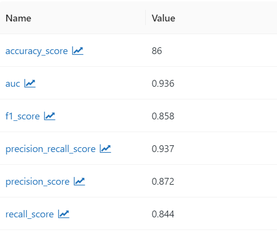

Comme on peut le voir ci dessus, le modèle BERT surpasse nettement les performances du modèle précédent. Cependant, l'entrainement de ce modèle nécessite une grosse ressource computationnelle et il a fallu utiliser un petit batch_size pour éviter un problème de ressources insufissantes. Dans notre cas, il a fallu attendre 4h (en comptant le preprocessing et l'encodage des données) pour que le modèle BERT s'entraine contre une vingtaine de minutes pour le modèle LSTM.

### Conclusion

Nous avons pu comparer une simple régression logistique à des modèles plus complexes dans le cadre d'une classification binaire de sentiment. La regression logistique montre des résultats correctes avec peu de données, cependant les réseaux de neurones (LSTM - BERT) montrent de meilleurs résultats en augmentant la quantité de données (1.5 Millions de tweet). Contrairement à la regression logistique, les réseaux de neurones sont capables d'apprendre des caractéristiques plus profondes et complexes du texte, en capturant des relations contextuelles entre les mots, ce qui les rend particulièrement adaptés à des tâches de traitement du langage naturel comme la classification du sentiment.  
De plus, avec l'augmentation de la taille du dataset, la capacité des réseaux de neurones à généraliser s'améliore, permettant d'obtenir des performances accrues par rapport à la régression logistique. Cela dit, il est important de noter que les réseaux de neurones nécessitent une puissance de calcul significativement plus importante et peuvent être plus coûteux en termes de temps et de ressources à entraîner.  
En conclusion, bien que la régression logistique puisse être un bon point de départ pour des projets de moindre envergure ou avec des ressources limitées, pour des tâches nécessitant une analyse détaillée et approfondie des textes, les réseaux de neurones offrent des avantages incontestables.